# Your Digest for Monday, Sep 09, 2024 11:59 PM

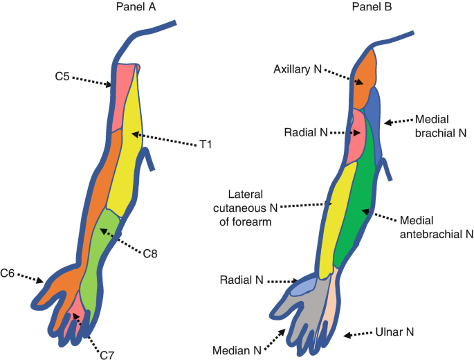

# Fever

## general approach

1. **Exclude** red flags
   1. High temperature
   2. Rash
   3. Change in mental status
   4. Dizziness
   5. Recent chemotherapy
   6. SOB / chest pain
2. **Clues** for each Diagnostic category (*MIMI*)
   1. Infection -
      1. Sick contacts, travel history, hospitalisation, occupational / epidemiological risk factors.
   2. Inflammatory - vasculitis, arthritis / gout, IBD, SLE
   3. Malignant -
      1. bone pain, constitutional symptoms, LOA, LOW
   4. Miscellaneous
      1. Drug induced
      2. Endocrine - hyperthyroidism, pancreatitis, Addison's
      3. Sarcoid

# Case discussion

What are the causes of altered behaviour? What circuits are involved with the development of behavioural abnormalities?

Kernig's Vs brudzinski sign and their LRs

- APLS is a *complication* of SLE ?
- what is C3D in the DAT profile?
- why does TB cause a low CRP? (Or is that the case)
- when can UPCR be falsely elevated? Check the pod cast
- Italian attribution algorithm
- side effects of azathioprine and MMF as these are one tier higher than hcq in the management of SLE flares.

# M & M

What is ESBL? Why is it a problem? What do we use to treat it?

# reflection

> [!Info] reflection  
> After writing down the *routine medications*, review the shutter problems to see if any are **contraindicated**.
- Evaluation of jaundice.
- STEMI daily ECG quiz (on LITFL?)
- aortic stenosis Vs sclerosis.
- features of apo on chest x-ray

Inhalers require a deep steady breath. Not a short sharp breath. Short sharp breaths will only make the mist deposit in the back of the throat.

> [!Clinic] reflection  
> Always check pallor and icterus and central cyanosis as part of the examination

# start journalling!

> [!info] 5 minutes every day  
> 3 positives and 3 negatives.

The receivers determines value.

Thank people

Only say things which add value.

1. Self reflection/ reading
2. Positive statement
3. Gratitude via thank you notes

Self awareness

**Have a Personal mission statement**  
Vision: a picture of the future you with to create.

Document inspiring patient stories.

- Always include "iatrogenic" as a aetiology for any complaint.

## Blood Urea Nitrogen (BUN) and Creatinine

> [!Info] Summary
> - Urea is a substance found in the blood. It is produced in the liver as a by product of protein metabolism.
> - It is eliminated by the kidney and is therefore used as a marker of renal function, albeit a poor one.
> - Urea is filtered and about 40% is reabsorbed and this is important for renal urea cycling which establishes a hypersmotic medulla.
> - Adh hormone regulates the amount of urea reabsorption.
> - urea is a poor marker of renal function because many physiology and pathologic processes alter it's serum concentration.

> "In Europe, the whole urea molecule is assayed, whereas in the United States only the nitrogen component of urea (the blood or serum urea nitrogen, i.e., BUN or SUN) is measured. The BUN, then, is roughly one-half (28/60 or 0.446) of the blood urea."

The reference range for urea is wide because many physiologic factor affect the concentration. ->

> The normal range of urea nitrogen in blood or serum is 5 to 20 mg/dl, or 1.8 to 7.1 mmol urea per liter. The range is wide because of normal variations due to protein intake, endogenous protein catabolism, state of hydration, hepatic urea synthesis, and renal urea excretion. A BUN of 15 mg/dl would represent significantly impaired function for a *woman in the thirtieth week of gestation*. Her higher glomerular filtration rate (GFR), expanded extracellular fluid volume, and anabolism in the developing fetus contribute to her relatively low BUN of 5 to 7 mg/dl. In contrast, the *rugged rancher* who eats in *excess of 125 g protein each day may have a normal BUN of 20 mg/dl*.

Daily urea production:

> The normal subject on a 70 g protein diet produces about 12 g of urea each day

About 10g of the produced urea is excreted by the kidneys.

Blood urea is test to measure the excreting capacity of the kidney.

> Two morphological distinct cells, principal cell (PC) and intercalated cell (IC), are present in the CNT and CCD [29, 75], and it is generally accepted that **PC and IC are responsible for K secretion and for K absorption, respectively**  
> Intercalated cells -> "in"

# Myotomes

Muscle power defects occurring with nerve root lesions:

> [!Clinic] How to test:  
> Test hip flexion -> knee extension -> toe extension -> plantar flexion to work your way down the spinal cord levels.

| Nerve | Symptoms | Signs |
| --- | --- | --- |
| L2-4 | Acute back pain radiating around the anterior leg into the knee and possibly foot | Decreased hip flexion, knee extension, leg abduction; decreased sensation in the anterior thigh down the medial aspect of the shin; diminished knee jerk in severe cases |
| L5 | Back pain radiating down the lateral leg to foot | Decreased foot dorsiflexion, toe extension, foot inversion and eversion; mild weakness of leg abduction in severe cases |
| S1 | Pain radiating down the posterior leg to foot; leg pain greater than back pain | Decreased leg extension, foot inversion, plantar flexion, and toe flexion; decreased sensation in the posterior leg and lateral foot; loss of ankle jerk |
| S2-4 | Sacral or buttock pain radiating down the posterior leg or into the perineum | Minimal weakness; bowel and bladder dysfunction |

> [!INFO] There's no need to test both knee extension and hip flexion
> 1. They are supplied by the same nerve roots
> 2. Knee extension (and at least one muscle of hip flexion (rectus femoris) are both supplied by the *femoral nerve*.  
>    So it's unlikely that one or other of knee extension and hip flexion would affected without the other.

# Dermatomes

[figure not shown]

# Lower limb nerves and actions

See [This](https://upload.wikimedia.org/wikipedia/commons/4/43/Gray835.png) and [This](https://upload.wikimedia.org/wikipedia/commons/9/9d/Gray832.png)

## Inhalers and types

[figure not shown]

# Pre-test and post-test probability

> [!info] Prevalence = pre-test probability
- **Prevalence** is **equivalent** to the probability that *any single patient in the population has the disease*.
- This is the same thing as **pre-test probability**

Therefore, if a person in a sports team develops chest pain, (they come from a population with low prevalence if MI), they are very unlikely to have an actual MI. They have a *low pre-test probability* of having MI.

Because of the low prevalence, it doesn't make sense to test every person in the sports team for ischemic heart disease.

On the other hand, a person who smokes heavily (i.e comes from the *population* of smokers) has a high pre-test probability of having an MI.  
Remember, they have a *high probability* but it's not a certainty. Thefore, in deciding to treat such a person, we are acknowledging and accepting that we have a *chance of over treating*. (Treating someone who didn't have an MI). We have to **determine what chance of over treatment we are comfortable with**, relative to the risk of under treatment. A diagnosis will never be 100% certain in the real world.

We manage patients based on "what is the chance that my diagnosis is right?"

In the sports player, the risk of under treatment is very low but the risk of over treatment is very high. In the smoker, the risk of over treatment is low and the risk of under treatment is high.

This is an alternative way of thinking about smoking as a *risk factor* for IHD.

The higher the risk of side effects of a treatment (for a condition), the higher we want probability of the patient having the disease to be, before deciding to treat. (Because over treating carries significant risk).

I.e low threshold for giving stat doses but high threshold for giving thrombolysis.

> [!NOTE] When to treat

> *Is the risk of side effects > or < the risk of the patient having the disease?*  
> If greater, don't treat.  
> If less, treat.

### Test characteristics

- Sensitivity tells us who has the disease
- specificity tells us doesn't have the disease
- positive predictive value tells us how much we can trust a positive answer and
- negative predictive value tells us how much we can trust a negative result.

> [!info] to do  
> What is the relationship between sensitivity and specificity and positive and negative predictive values?

### sensitivity

How to visualize sensitivity:  
Think about a very sensitive richter scale needle designed to sense earthquakes.

- the needle is so jittery that nearby vehicles will set it off: it has high false positives.
- however even the tiniest earthquake will also registered as positive: it has high true positives.
- because it is so sensitive every earthquake will register as positive. It has low false negatives.
- because the needle is so sensitive it will never classify anything tremmor as negative; it has **low true negatives as well**. In other word it just doesn't classify things as negative.
- **sensitivity; how jittery sensitive is the needle?**
- on the other hand think of a specific test as a highly damped needle on a richter scale.
- since it is highly damped only a strong earthquake will register as positive;
- small earthquakes will not be detected. The test has high false negatives.
- since the test classifies many types of non earthquake vibrations as negative, the true negatives will also be high.
- since the test will not easily register vibrations as positive the rate of false positive will be low.
- however, since the needle is highly damped moderate intensity earthquakes will also be registered as negative; highly specific test will also have low true positives.
- **specificity; how damped is the needle**

Simplest way to understand this is through examples:

- For a patient with suspected DVT, the pretest probability will be calculated by the Well's score.
- Then a test with a known +ve [[Statistics#Likelihood ratio|likelihood ratio]] is performed. (eg. CTPA or D-dimers)
- The pretest probability multiplied by the +ve likelihood ration gives the **post-test probability**

WHO waist circumference cutoffs for central obesity

| Ethnicity | Gender | Waist circumference (cm) |
| --- | --- | --- |
| Caucasians | Men | >94 |
|  | Women | >80 |
| Asians | Men | >90 |
|  | Women | >80 |
| [Source](https://www.matilda.org/en/matilda-wellness/health-topics/1841-waist-measurement-for-central-obesity) |  |  |

NAFLD is considered the **hepatic component of metabolic syndrome**.